# Data Manupulation in R

# Data management in R

In this section we will discuss about data management process, basic data cleaning and management in R. For detail notes use the [MAP training material](https://malaria-atlas-project.gitlab.io/intro-to-spatial-analysis-for-infectious-diseases/02_datahandling.html) training material. For demonstration, we will use the routine malaria surveillance data extracted from DHIS2.

## Outline

- Reading data into R
- Explore data
- Data manipulation

Data can be defined as a collection of facts that can be used to draw a conclusion, make predictions and assist decision making.

Public health data may originate from various sources including:

- Routine disease surveillance system - DHIS2

- Research and surveys - DHS, MIS, SPA

- Administrative - logistic data

- Vital statistics - birth, death

- Literature and reports

## Reading data

This section will focus on how to read data in R. R has the functionality to import various types of data. One of the most common file types we work with are `.csv` files, but we can also import `.dta` files and `.xlsx` files among others.

We can **import .csv** files into RStudio using the base function `read.csv().` In this function we insert the file path to the data we wish to import. Note that as we have set up a project, this is our base directory so file paths stem from where the project is saved. We can assign the imported dataset to an object, here called `routine_data`, using the `<-` operator to store it in our environment.

For data management, we will use the `tidyverse`package using *install.packages()* function.

Check all the required package

```r
library(tidyverse) #data management
library(hablar) #convert variable type
library(janitor)#clean names
library(haven) #to read and save '.dta' files
library(lubridate)# For date
```

```r
#remove(list=ls()) # clear your directory
my.dir <- paste(getwd(),"/",sep="")
routine_data <-read.csv("C:/Users/user/Documents/Part 2/routine_data.csv") |>
    clean_names()
```

Other data types can easily be read into R using different packages available. `.xlsx` files can easily read into R using the `read_excel()` function from the **readxl** package. Stata files (.dta) can be read in using the `read_dta()` function from the `Haven` package or `read.dta()` function from the `foreign` package. Both `Haven and readxl` are parts of the tidyverse package however we need to install the `foreign` package separately.

```r
# Examples, not run
library(readxl)
xlsx_data <- read_xls("data",sheet = "sheet1", col_names = TRUE, na = "NA")

library(haven)
stata_data <- read_dta("stata_file.dta")
```

Whilst `read.csv()` is the most common way to read data into R, there is the alternative `read_csv()` function (note the underscore). This is part of the `tidyverse` group of packages and is often a better option for reading in CSV files. This function is quicker, it reads the data in as a tibble instead of a data frame and allows for non standard variable namesm amongst other benefits.

```r
routine_data <- read_csv("C:/Users/user/Documents/Part 2/routine_data.csv")
```

There are various options we can use when importing data, such as whether to include headers, what character to use for decimal points, what to import as missing values. To explore these options you can look at the help pages e.g. `?read_csv`.

### Explore the data

Knowing your dataset well from file size to data types is another crucial step prior to hands-on data cleaning.

To look at how the data looks like either by clicking on it in the global environment window or by typing the command `View(routine_data)` which opens up a window displaying the data. Alternatively, we may just want to look at a few rows. We can do this by using the `head()` function, which shows us the first n rows of data.

To view the top five rows of the_data frame:

```r
head(routine_data, 5)
```

```
# A tibble: 5 × 16
  region zone  distr…¹ Month  Year date  test_…² confi…³ confi…⁴ confi…⁵ confi…⁶
  <chr>  <chr> <chr>   <chr> <dbl> <chr>   <dbl>   <dbl>   <dbl>   <dbl>   <dbl>
1 Addis… Addi… Addis … July   2021 1/07…      97       3       1       0       2
2 Addis… Addi… Addis … Augu…  2021 1/08…     148      70       0       1      69
3 Addis… Addi… Addis … Sept…  2021 1/09…     142       5       0       0       5
4 Addis… Addi… Addis … Octo…  2021 1/10…     190      93       0       6      87
5 Addis… Addi… Addis … Nove…  2021 1/11…     194      87       6       3      78
# … with 5 more variables: population <dbl>, pop_5 <dbl>, pop_514 <dbl>,
#   pop_15 <dbl>, affected_districts <chr>, and abbreviated variable names
#   ¹district, ²test_performed, ³confirmed_all, ⁴confirmed_u5, ⁵confirmed_5_14,
#   ⁶confirmed_15
```

To understand the structure of the data we can use the `str()` command or `glimpse.`

```r
str(routine_data)
```

```
spc_tbl_ [11,604 × 16] (S3: spec_tbl_df/tbl_df/tbl/data.frame)
 $ region            : chr [1:11604] "Addis Ababa" "Addis Ababa" "Addis Ababa" "Addis Ababa" ...
 $ zone              : chr [1:11604] "Addis Ketema" "Addis Ketema" "Addis Ketema" "Addis Ketema" ...
 $ district          : chr [1:11604] "Addis Ketema (AA)" "Addis Ketema (AA)" "Addis Ketema (AA)" "Addis Ketema (AA)" ...
 $ Month             : chr [1:11604] "July" "August" "September" "October" ...
 $ Year              : num [1:11604] 2021 2021 2021 2021 2021 ...
 $ date              : chr [1:11604] "1/07/2021" "1/08/2021" "1/09/2021" "1/10/2021" ...
 $ test_performed    : num [1:11604] 97 148 142 190 194 194 146 189 243 184 ...
 $ confirmed_all     : num [1:11604] 3 70 5 93 87 25 62 72 18 23 ...
 $ confirmed_u5      : num [1:11604] 1 0 0 0 6 0 0 0 0 0 ...
 $ confirmed_5_14    : num [1:11604] 0 1 0 6 3 1 2 2 0 2 ...
 $ confirmed_15      : num [1:11604] 2 69 5 87 78 24 60 70 18 21 ...
 $ population        : num [1:11604] 351095 351095 351095 351095 351095 ...
 $ pop_5             : num [1:11604] 50742 50742 50742 50742 50742 ...
 $ pop_514           : num [1:11604] 88159 88159 88159 88159 88159 ...
 $ pop_15            : num [1:11604] 212194 212194 212194 212194 212194 ...
 $ affected_districts: chr [1:11604] "Not_affected" "Not_affected" "Not_affected" "Not_affected" ...
 - attr(*, "spec")=
  .. cols(
  ..   region = col_character(),
  ..   zone = col_character(),
  ..   district = col_character(),
  ..   Month = col_character(),
  ..   Year = col_double(),
  ..   date = col_character(),
  ..   test_performed = col_double(),
  ..   confirmed_all = col_double(),
  ..   confirmed_u5 = col_double(),
  ..   confirmed_5_14 = col_double(),
  ..   confirmed_15 = col_double(),
  ..   population = col_double(),
  ..   pop_5 = col_double(),
  ..   pop_514 = col_double(),
  ..   pop_15 = col_double(),
  ..   affected_districts = col_character()
  .. )
 - attr(*, "problems")=<externalptr>
```

```r
glimpse(routine_data)
```

```
Rows: 11,604
Columns: 16
$ region             <chr> "Addis Ababa", "Addis Ababa", "Addis Ababa", "Addis…
$ zone               <chr> "Addis Ketema", "Addis Ketema", "Addis Ketema", "Ad…
$ district           <chr> "Addis Ketema (AA)", "Addis Ketema (AA)", "Addis Ke…
$ Month              <chr> "July", "August", "September", "October", "November…
$ Year               <dbl> 2021, 2021, 2021, 2021, 2021, 2021, 2021, 2021, 202…
$ date               <chr> "1/07/2021", "1/08/2021", "1/09/2021", "1/10/2021",…
$ test_performed     <dbl> 97, 148, 142, 190, 194, 194, 146, 189, 243, 184, 16…
$ confirmed_all      <dbl> 3, 70, 5, 93, 87, 25, 62, 72, 18, 23, 15, 43, 17, 3…
$ confirmed_u5       <dbl> 1, 0, 0, 0, 6, 0, 0, 0, 0, 0, 0, 2, 2, 0, 0, 0, 3, …
$ confirmed_5_14     <dbl> 0, 1, 0, 6, 3, 1, 2, 2, 0, 2, 0, 4, 1, 0, 0, 0, 0, …
$ confirmed_15       <dbl> 2, 69, 5, 87, 78, 24, 60, 70, 18, 21, 15, 37, 14, 3…
$ population         <dbl> 351095.1, 351095.1, 351095.1, 351095.1, 351095.1, 3…
$ pop_5              <dbl> 50741.83, 50741.83, 50741.83, 50741.83, 50741.83, 5…
$ pop_514            <dbl> 88159.40, 88159.40, 88159.40, 88159.40, 88159.40, 8…
$ pop_15             <dbl> 212193.8, 212193.8, 212193.8, 212193.8, 212193.8, 2…
$ affected_districts <chr> "Not_affected", "Not_affected", "Not_affected", "No…
```

From the output, we can also see that the data frame consists of 11604 observations (rows) and 16 variables (columns). Each variable’s name and data type is also listed. The dataset can be read as data.frame, lists, tbl_df, spatial, etc. To see the class of the the dataset we can use the code:

```r
class(routine_data)
```

```
[1] "spec_tbl_df" "tbl_df"      "tbl"         "data.frame"
```

For a dataframe we can select the nth row, or the nth column using square brackets (note where the comma is paced).

```r
head(routine_data[,2], 5) #second column
```

```
# A tibble: 5 × 1
  zone
  <chr>
1 Addis Ketema
2 Addis Ketema
3 Addis Ketema
4 Addis Ketema
5 Addis Ketema
```

```r
routine_data[1,] #firts row
```

```
# A tibble: 1 × 16
  region zone  distr…¹ Month  Year date  test_…² confi…³ confi…⁴ confi…⁵ confi…⁶
  <chr>  <chr> <chr>   <chr> <dbl> <chr>   <dbl>   <dbl>   <dbl>   <dbl>   <dbl>
1 Addis… Addi… Addis … July   2021 1/07…      97       3       1       0       2
# … with 5 more variables: population <dbl>, pop_5 <dbl>, pop_514 <dbl>,
#   pop_15 <dbl>, affected_districts <chr>, and abbreviated variable names
#   ¹district, ²test_performed, ³confirmed_all, ⁴confirmed_u5, ⁵confirmed_5_14,
#   ⁶confirmed_15
```

To view all variable names with the `names()`, `colnames()` , and `variable.names()` function.

```r
colnames(routine_data)
```

```
 [1] "region"             "zone"               "district"
 [4] "Month"              "Year"               "date"
 [7] "test_performed"     "confirmed_all"      "confirmed_u5"
[10] "confirmed_5_14"     "confirmed_15"       "population"
[13] "pop_5"              "pop_514"            "pop_15"
[16] "affected_districts"
```

```r
names(routine_data)
```

```
 [1] "region"             "zone"               "district"
 [4] "Month"              "Year"               "date"
 [7] "test_performed"     "confirmed_all"      "confirmed_u5"
[10] "confirmed_5_14"     "confirmed_15"       "population"
[13] "pop_5"              "pop_514"            "pop_15"
[16] "affected_districts"
```

```r
variable.names(routine_data)
```

```
 [1] "region"             "zone"               "district"
 [4] "Month"              "Year"               "date"
 [7] "test_performed"     "confirmed_all"      "confirmed_u5"
[10] "confirmed_5_14"     "confirmed_15"       "population"
[13] "pop_5"              "pop_514"            "pop_15"
[16] "affected_districts"
```

To view variable with the position number:

```r
names(routine_data)[5]
```

```
[1] "Year"
```

These can be determined by either the`str()or glimpse()` function or the more explicit function. There are several incorrect data types in this dataset, but let’s continue using the “date” variable to demonstrate how to identify and update these errors:

```r
typeof(routine_data$date)
```

```
[1] "character"
```

String inconsistencies: This includes typos, capitalization errors, misplaced punctuation, or similar character data errors that might interfere with data analysis. Take for instance our “year” column.

```r
unique(routine_data$Year)
```

```
[1] 2021 3021   21
```

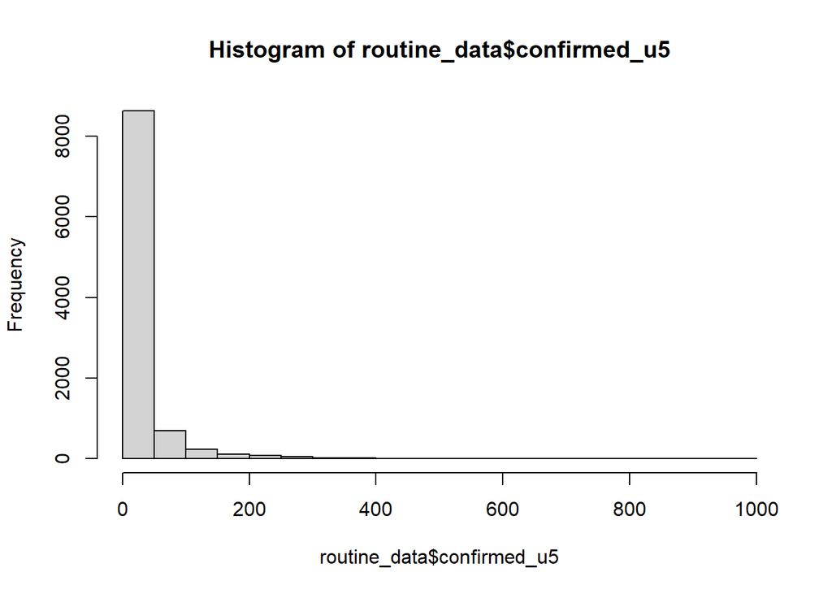

```r
hist(routine_data$confirmed_u5)
```

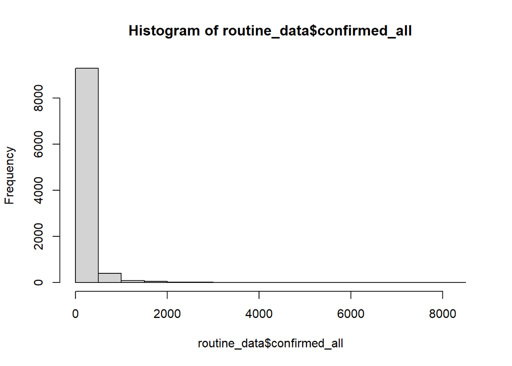

```r
hist(routine_data$confirmed_all)
```

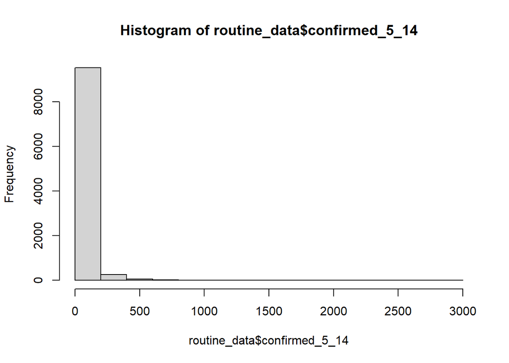

```r
hist(routine_data$confirmed_5_14)
```

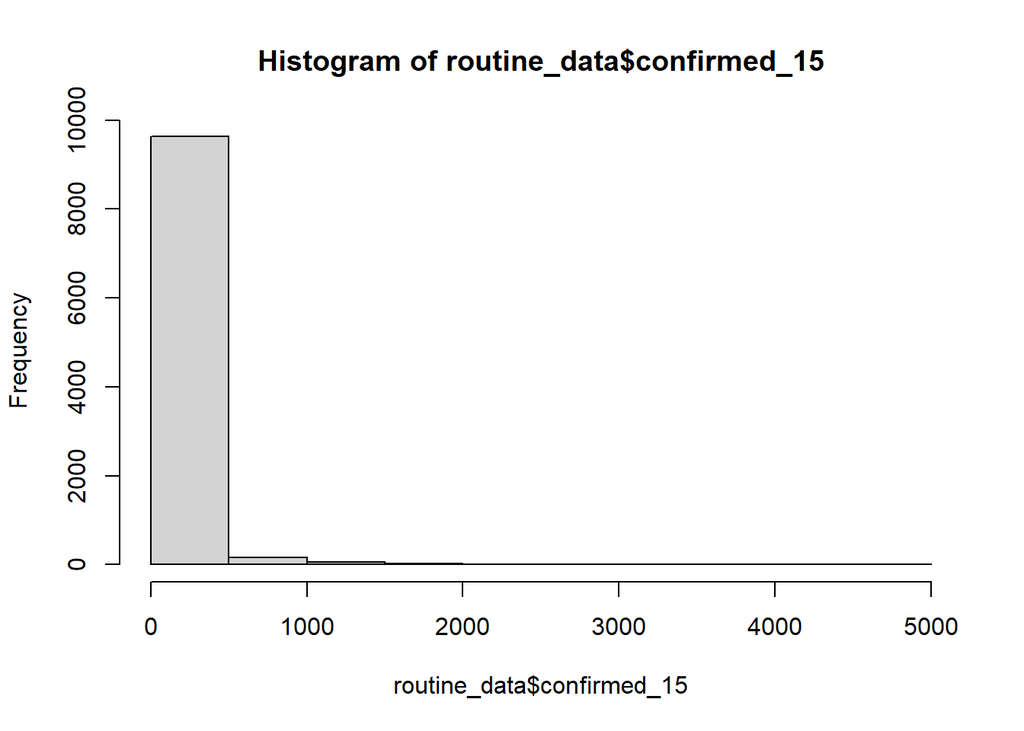

```r
hist(routine_data$confirmed_15)
```

Data cleaning is one of the most important steps for analysis! No matter where your data comes from, always be sure the completeness, consistency, and trustworthiness of data before analyzing and utilizing the data. Once you get cleaned and organized, you can perform analysis to find clear and objective answers to any data question.

**Important**

Task 1:

- Import the `am_data.csa` file using the `read_csv()` function and call the object "my_data"
- Explore the data structure
- inspect the top and tail data rows
- check the name and lists of variables
- check the data types of Month, Year and date variables

## Data manipulation in Tidyverse

In this section we introduce you to the `tidyverse` packages and show how these functions can be used to explore, manipulate and analyse data. We have already loaded this package with the command `library(tidyverse).`

Tidyverse is a collection of R packages for data science, designed to make cleaning and analyses of data easy and tidy. It uses a range of packages and functions, along with the pipe operator, `%>%`, for version 4.1 and greater `|>`to produce easily readable and reproducible code.

We will start by looking at the basic data manupulation.

Let’s start to manipulate our clean data using the functions from the tidyverse.We will cover the following simple, commonly used functions in tidyverse:

- select
- filter
- rename
- mutate
- group_by
- summarise
- pipes

We will continue this investigation using the clean data `routine_data.csv` dataset we imported into R in the previous section

#### Select

Firstly, we can use `select()` to select columns from the data frame. The first argument is the name of the data frame, followed by the columns you wish to keep. Here we will just select the test performed, confirmed numbers of malaria cases, along with the location and date information.

```r
dplyr::select(routine_data,region,zone,district,
       Month,date,confirmed_all,test_performed)
```

```
# A tibble: 11,604 × 7
   region      zone         district          Month     date     confi…¹ test_…²
   <chr>       <chr>        <chr>             <chr>     <chr>      <dbl>   <dbl>
 1 Addis Ababa Addis Ketema Addis Ketema (AA) July      1/07/20…       3      97
 2 Addis Ababa Addis Ketema Addis Ketema (AA) August    1/08/20…      70     148
 3 Addis Ababa Addis Ketema Addis Ketema (AA) September 1/09/20…       5     142
 4 Addis Ababa Addis Ketema Addis Ketema (AA) October   1/10/20…      93     190
 5 Addis Ababa Addis Ketema Addis Ketema (AA) November  1/11/20…      87     194
 6 Addis Ababa Addis Ketema Addis Ketema (AA) December  1/12/20…      25     194
 7 Addis Ababa Addis Ketema Addis Ketema (AA) January   1/01/20…      62     146
 8 Addis Ababa Addis Ketema Addis Ketema (AA) February  1/02/20…      72     189
 9 Addis Ababa Addis Ketema Addis Ketema (AA) March     1/03/20…      18     243
10 Addis Ababa Addis Ketema Addis Ketema (AA) April     1/04/20…      23     184
# … with 11,594 more rows, and abbreviated variable names ¹confirmed_all,
#   ²test_performed
```

#### Filter

```r
filter(routine_data,

       region == "SNNP")
```

```
# A tibble: 1,728 × 16
   region zone        district Month  Year date  test_…¹ confi…² confi…³ confi…⁴
   <chr>  <chr>       <chr>    <chr> <dbl> <chr>   <dbl>   <dbl>   <dbl>   <dbl>
 1 SNNP   Ale Special Alle Sp… July   2021 1/07…     552     261      41      72
 2 SNNP   Ale Special Alle Sp… Augu…  2021 1/08…     415     224      21      74
 3 SNNP   Ale Special Alle Sp… Sept…  2021 1/09…     473      78      11      19
 4 SNNP   Ale Special Alle Sp… Octo…  2021 1/10…     397      71       8      31
 5 SNNP   Ale Special Alle Sp… Nove…  2021 1/11…     381      79       6      21
 6 SNNP   Ale Special Alle Sp… Dece…  2021 1/12…     627     161      16      39
 7 SNNP   Ale Special Alle Sp… Janu…  2021 1/01…     561     166      23      40
 8 SNNP   Ale Special Alle Sp… Febr…  2021 1/02…     310      61       4      15
 9 SNNP   Ale Special Alle Sp… March  2021 1/03…     283      59       4       9
10 SNNP   Ale Special Alle Sp… April  2021 1/04…     288     111      31      22
# … with 1,718 more rows, 6 more variables: confirmed_15 <dbl>,
#   population <dbl>, pop_5 <dbl>, pop_514 <dbl>, pop_15 <dbl>,
#   affected_districts <chr>, and abbreviated variable names ¹test_performed,
#   ²confirmed_all, ³confirmed_u5, ⁴confirmed_5_14
```

```r
filter(routine_data,

       confirmed_u5 >500)
```

```
# A tibble: 16 × 16
   region        zone  distr…¹ Month  Year date  test_…² confi…³ confi…⁴ confi…⁵
   <chr>         <chr> <chr>   <chr> <dbl> <chr>   <dbl>   <dbl>   <dbl>   <dbl>
 1 Gambella      Gamb… Gambel… Octo…  2021 1/10…    5221    2317     701     408
 2 Gambella      Gamb… Gambel… Nove…  2021 1/11…    5285    2556     972     582
 3 Gambella      Itan… Itang   Dece…  2021 1/12…     504    1271     744     256
 4 Somali        Afder Barey   Augu…  2021 1/08…    2202    2192     745     742
 5 Somali        Afder Barey   Octo…  2021 1/10…    1950    1950     653     635
 6 Beneshangul … Asso… Sherko… July   2021 1/07…    5132    3984     861    1362
 7 Amhara        Awi   Jawi    Sept…  2021 1/09…    8710    3051     517     794
 8 Amhara        Awi   Jawi    Octo…  2021 1/10…   11391    3616     595     999
 9 Amhara        Cent… Gonder… Octo…  2021 1/10…   10287    4593     555    1560
10 Amhara        Cent… Gonder… Nove…  2021 1/11…   11089    4564     571    1581
11 Amhara        Sout… Dera (… June   2021 1/06…   13008    6017     916    2068
12 Amhara        Sout… Fogera  Octo…  2021 1/10…   14768    5357     521    1920
13 Amhara        Sout… Fogera  Nove…  2021 1/11…   19448    8367     954    2905
14 Amhara        Sout… Fogera  Dece…  2021 1/12…   10552    4078     648    1452
15 SNNP          Silte Sankura Octo…  2021 1/10…    4781    2144     733     587
16 SNNP          Wola… Boloso… May    2021 1/05…   11681    3762     503    1628
# … with 6 more variables: confirmed_15 <dbl>, population <dbl>, pop_5 <dbl>,
#   pop_514 <dbl>, pop_15 <dbl>, affected_districts <chr>, and abbreviated
#   variable names ¹district, ²test_performed, ³confirmed_all, ⁴confirmed_u5,
#   ⁵confirmed_5_14
```

```r
filter(routine_data,

       (region == "Amhara" | region == "Afar") &

       confirmed_u5 >=500)
```

```
# A tibble: 8 × 16
  region zone  distr…¹ Month  Year date  test_…² confi…³ confi…⁴ confi…⁵ confi…⁶
  <chr>  <chr> <chr>   <chr> <dbl> <chr>   <dbl>   <dbl>   <dbl>   <dbl>   <dbl>
1 Amhara Awi   Jawi    Sept…  2021 1/09…    8710    3051     517     794    1740
2 Amhara Awi   Jawi    Octo…  2021 1/10…   11391    3616     595     999    2022
3 Amhara Cent… Gonder… Octo…  2021 1/10…   10287    4593     555    1560    2478
4 Amhara Cent… Gonder… Nove…  2021 1/11…   11089    4564     571    1581    2412
5 Amhara Sout… Dera (… June   2021 1/06…   13008    6017     916    2068    3033
6 Amhara Sout… Fogera  Octo…  2021 1/10…   14768    5357     521    1920    2916
7 Amhara Sout… Fogera  Nove…  2021 1/11…   19448    8367     954    2905    4508
8 Amhara Sout… Fogera  Dece…  2021 1/12…   10552    4078     648    1452    1978
# … with 5 more variables: population <dbl>, pop_5 <dbl>, pop_514 <dbl>,
#   pop_15 <dbl>, affected_districts <chr>, and abbreviated variable names
#   ¹district, ²test_performed, ³confirmed_all, ⁴confirmed_u5, ⁵confirmed_5_14,
#   ⁶confirmed_15
```

We may want to use the `filter` function to identify erroneous data in our dataset, for example, we can identify situations where the number of people confirmed with malaria is higher than the number tested.

```r
filter(routine_data,

       confirmed_all>test_performed)
```

```
# A tibble: 97 × 16
   region   zone       distr…¹ Month  Year date  test_…² confi…³ confi…⁴ confi…⁵
   <chr>    <chr>      <chr>   <chr> <dbl> <chr>   <dbl>   <dbl>   <dbl>   <dbl>
 1 Afar     Zone 2     Abaala  Augu…  2021 1/08…      10      12       9       1
 2 Afar     Zone 4     Euwa    Octo…  2021 1/10…     191     243      61      64
 3 Gambella Agniwa     Jore    Dece…  2021 1/12…      79     158      29      40
 4 Gambella Agniwa     Jore    April  2021 1/04…      63      73      43      22
 5 Gambella Agniwa     Jore    May    2021 1/05…      75      84      43      23
 6 Gambella Itang Spe… Itang   Dece…  2021 1/12…     504    1271     744     256
 7 Gambella Itang Spe… Itang   Janu…  2021 1/01…     864     867     308     155
 8 Gambella Majang     Mengesh May    2021 1/05…     118     198      46      41
 9 Gambella Nuer       Lare    Janu…  2021 1/01…     132     201      65      28
10 Gambella Nuer       Makuey  Janu…  2021 1/01…     243     360     112      93
# … with 87 more rows, 6 more variables: confirmed_15 <dbl>, population <dbl>,
#   pop_5 <dbl>, pop_514 <dbl>, pop_15 <dbl>, affected_districts <chr>, and
#   abbreviated variable names ¹district, ²test_performed, ³confirmed_all,
#   ⁴confirmed_u5, ⁵confirmed_5_14
```

#### Rename

```r
rename(routine_data,

       conf_u5 =confirmed_u5)
```

```
# A tibble: 11,604 × 16
   region      zone    distr…¹ Month  Year date  test_…² confi…³ conf_u5 confi…⁴
   <chr>       <chr>   <chr>   <chr> <dbl> <chr>   <dbl>   <dbl>   <dbl>   <dbl>
 1 Addis Ababa Addis … Addis … July   2021 1/07…      97       3       1       0
 2 Addis Ababa Addis … Addis … Augu…  2021 1/08…     148      70       0       1
 3 Addis Ababa Addis … Addis … Sept…  2021 1/09…     142       5       0       0
 4 Addis Ababa Addis … Addis … Octo…  2021 1/10…     190      93       0       6
 5 Addis Ababa Addis … Addis … Nove…  2021 1/11…     194      87       6       3
 6 Addis Ababa Addis … Addis … Dece…  2021 1/12…     194      25       0       1
 7 Addis Ababa Addis … Addis … Janu…  2021 1/01…     146      62       0       2
 8 Addis Ababa Addis … Addis … Febr…  2021 1/02…     189      72       0       2
 9 Addis Ababa Addis … Addis … March  2021 1/03…     243      18       0       0
10 Addis Ababa Addis … Addis … April  2021 1/04…     184      23       0       2
# … with 11,594 more rows, 6 more variables: confirmed_15 <dbl>,
#   population <dbl>, pop_5 <dbl>, pop_514 <dbl>, pop_15 <dbl>,
#   affected_districts <chr>, and abbreviated variable names ¹district,
#   ²test_performed, ³confirmed_all, ⁴confirmed_5_14
```

#### Mutate

Next, we can add new variables to the dataset or change existing variables using `mutate()`. Mutate allows us to assign new variables using the `=` sign. For example, if we wanted to create a variable of the incidence rate of malaria in under five children per 1000 under five population we could write:

```r
mutate(routine_data,

       incidence_rate = (confirmed_u5/pop_5)*1000)
```

```
# A tibble: 11,604 × 17
   region      zone    distr…¹ Month  Year date  test_…² confi…³ confi…⁴ confi…⁵
   <chr>       <chr>   <chr>   <chr> <dbl> <chr>   <dbl>   <dbl>   <dbl>   <dbl>
 1 Addis Ababa Addis … Addis … July   2021 1/07…      97       3       1       0
 2 Addis Ababa Addis … Addis … Augu…  2021 1/08…     148      70       0       1
 3 Addis Ababa Addis … Addis … Sept…  2021 1/09…     142       5       0       0
 4 Addis Ababa Addis … Addis … Octo…  2021 1/10…     190      93       0       6
 5 Addis Ababa Addis … Addis … Nove…  2021 1/11…     194      87       6       3
 6 Addis Ababa Addis … Addis … Dece…  2021 1/12…     194      25       0       1
 7 Addis Ababa Addis … Addis … Janu…  2021 1/01…     146      62       0       2
 8 Addis Ababa Addis … Addis … Febr…  2021 1/02…     189      72       0       2
 9 Addis Ababa Addis … Addis … March  2021 1/03…     243      18       0       0
10 Addis Ababa Addis … Addis … April  2021 1/04…     184      23       0       2
# … with 11,594 more rows, 7 more variables: confirmed_15 <dbl>,
#   population <dbl>, pop_5 <dbl>, pop_514 <dbl>, pop_15 <dbl>,
#   affected_districts <chr>, incidence_rate <dbl>, and abbreviated variable
#   names ¹district, ²test_performed, ³confirmed_all, ⁴confirmed_u5,
#   ⁵confirmed_5_14
```